# Assignment_2

Dan Rodrigues

06/10/2021

## Pre-requisites

If using Ubuntu, run “sudo apt-get install libxml2-dev”. Then install the following packages via the R console:

- rvest
- xml2
- tidyverse
- Stat2Data

(Do so via : “install.packages(package_name)”)

Now begin by loading Tidyverse (for ggplot2) and Stat2Data (for “Hawks” data set), after which we construct a smaller custom data set for subsequent activities.

```r
# Import libraries
library(tidyverse)
library(Stat2Data)

# Load Hawks data set
data("Hawks")

# Construct smaller data set by dropping rows with N/A's
hawksSmall <- drop_na(select(Hawks, Age, Day, Month, Year, CaptureTime, Species, Wing, Weight, Tail))
```

## 1) Visualisation

### 1.1) Types of variables

```r
# Use dim() function to find no. of rows and columns
hawksSmallDim <- dim(hawksSmall)
rows <- hawksSmallDim[1] # => 897 rows
cols <- hawksSmallDim[2] # => 9 columns

# Use head() function to display top 5 rows of data frame
hawksSmallHead <- head(hawksSmall)
print.data.frame(head(hawksSmallHead))
```

```
##   Age Day Month Year CaptureTime Species Wing Weight Tail
## 1   I  19     9 1992       13:30      RT  385    920  219
## 2   I  22     9 1992       10:30      RT  376    930  221
## 3   I  23     9 1992       12:45      RT  381    990  235
## 4   I  23     9 1992       10:50      CH  265    470  220
## 5   I  27     9 1992       11:15      SS  205    170  157
## 6   I  28     9 1992       11:25      RT  412   1090  230
```

The following variables are present, with outlined data types:

- Month = Discrete
- Species = Categoric
- Age = Categoric (Binary)
- Wing = Continuous
- Weight = Continuous

### 1.3) Generate a histogram

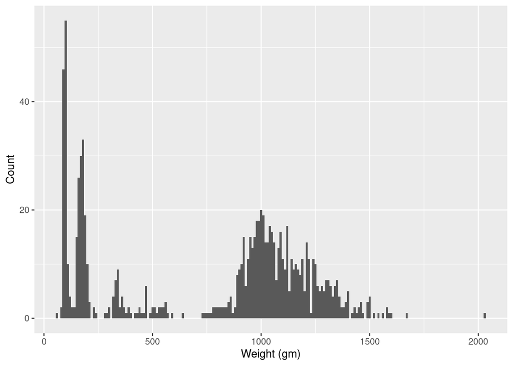

```r
# Generate histogram of weights of hawks via ggplot and geom_histogram
ggplot(data = hawksSmall, mapping = aes(x=Weight)) +
  geom_histogram(binwidth=10) +
  xlab("Weight (gm)") +
  ylab("Count")
```

An aesthetic is a mapping from a variable to a plot feature / visual cue. Here, weight is mapped to horizontal position (and count is mapped to vertical position)

The data distribution appears to be Bimodal, indicated by the presence of two regional peaks in histogram count in the plot at approximately 200 gm and 1000 gm.

### 1.4) Generate a density plot

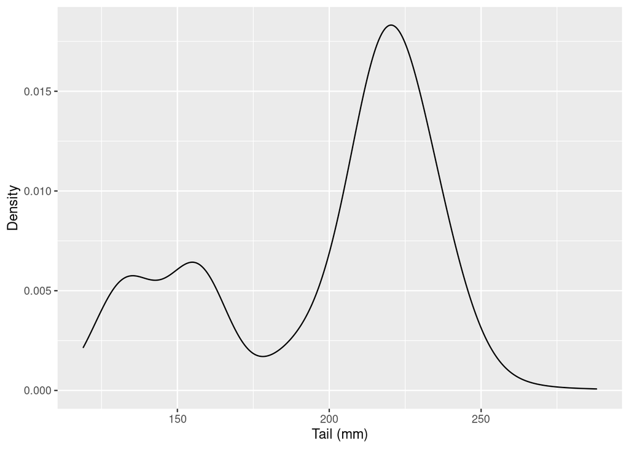

```r
# Generate a density plot of tail lengths of hawks via ggplot and geom_density
ggplot(data = hawksSmall, mapping = aes(x=Tail)) +
  geom_density() +
  xlab("Tail (mm)") +
  ylab("Density")
```

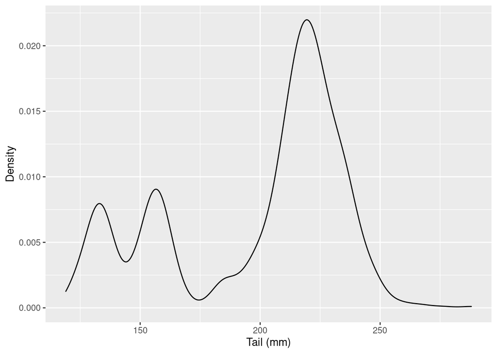

```r
# Recreate, but with adjust = 0.5
# (adjust=1.0) is same as original
ggplot(data = hawksSmall, mapping = aes(x=Tail)) +
  geom_density(adjust=0.5) +
  xlab("Tail (mm)") +
  ylab("Density")
```

The adjust argument modifies the bandwidth of the kernel, i.e. modifies the strength of the smoothing operation, with a smaller adjust value providing less smoothing, and hence resulting in a seemingly higher frequency curve.

The data distribution appears to be Trimodal.

We now attempt to recreate some provided plots:

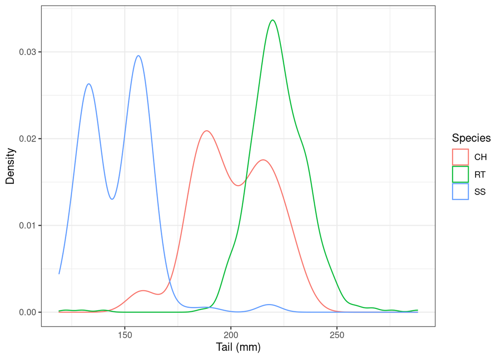

```r
ggplot(data = hawksSmall, mapping = aes(x=Tail, color=Species)) +
  geom_density(adjust=1.0) +
  xlab("Tail (mm)") +
  ylab("Density") +
  theme_bw()
```

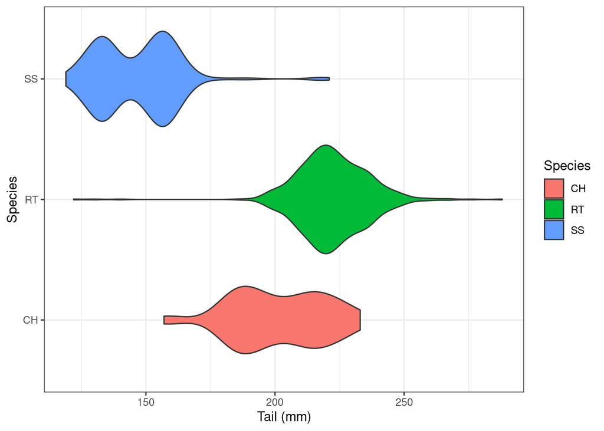

```r
ggplot(data = hawksSmall, mapping = aes(x=Tail, y=Species, fill = Species)) +
  geom_violin() +
  xlab("Tail (mm)") +
  ylab("Species") +
  theme_bw()
```

### 1.5) Scatter Plots

The plot has 4 aesthetics (mappings from features to visual cues):

- Tail length -> horizontal position
- Weight -> vertical position
- Species -> colour
- Species -> shape

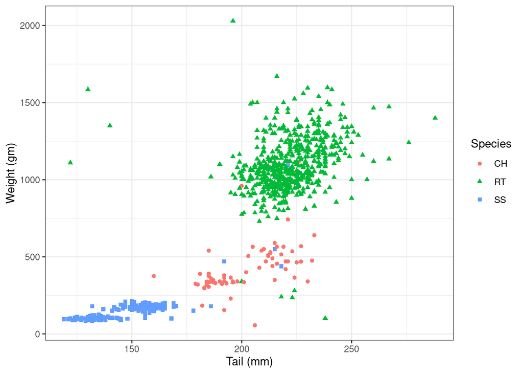

```r
ggplot(data = hawksSmall, mapping = aes(x=Tail, y=Weight, color=Species, shape=Species)) +
  geom_point() +
  xlab("Tail (mm)") +
  ylab("Weight (gm)") +
  theme_bw()
```

### 1.6) Trend lines and facet wraps

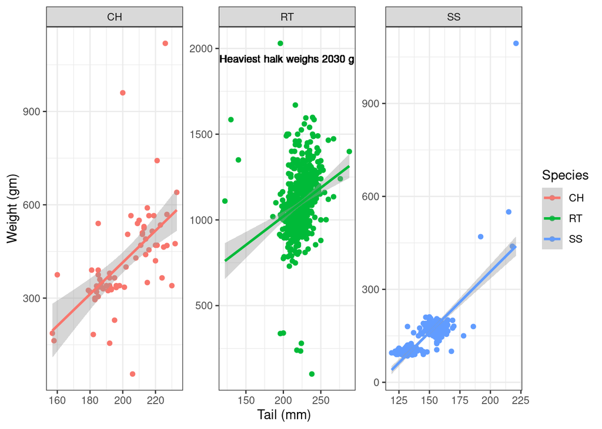

```r
# Extract maximum data for annotation
heaviest_halk <- max(filter(hawksSmall)$Weight, na.rm = TRUE)

ggplot(data = hawksSmall, mapping = aes(x=Tail, y=Weight, color=Species)) +
  geom_point() +
  geom_smooth(formula = y ~ x, method="lm") +
  facet_wrap(~Species, scales="free") +
  xlab("Tail (mm)") +
  ylab("Weight (gm)") +
  theme_bw() +
  geom_text(x=204.5, y=1940, label=paste("Heaviest halk weighs", heaviest_halk, "g"), show.legend=FALSE, size=3.1, color="black")
```

Visual cues:

- Horizontal position (tail)
- Vertical position (weight)
- Colour (species)

Based on plot, can say that tail length and weight appear to be positively correlated (i.e. as tail length increases, the width of the hawk also increases).

## 2) Data Wrangling

### 2.1) Select and filter functions

```r
# Create hSF data frame containing "Wing", "Weight", "Tail" columns, with rows belonging to species of Red-Tailed Hawks (RT) and weight >= 1kg
hSF <- hawksSmall %>%
          filter(Species == "RT" & Weight >= 1000) %>%
          select(Wing, Weight, Tail)

print.data.frame(head(hSF))
```

```
##   Wing Weight Tail
## 1  412   1090  230
## 2  412   1210  210
## 3  405   1120  238
## 4  393   1010  222
## 5  371   1010  217
## 6  390   1120  213
```

hSF has dimensions 398x3 (found using “dim()” command).

hSF has 3 variables (wing, weight, tail).

hSF has 398 observations or “cases” (a case is an expeimental unit from which data is collected, e.g. an indivdual hawk in this case).

You would communicate this information to a Machine Learning (ML) practitioner by saying that the dataset has 3 features (corresponding to the variables), and that the dataset is of size 398, or has 398 samples (or data points).

### 2.2) Arrange function

```r
# Use arrange function to sort hSF so rows appear in increasing order of wing span
rearranged_hSF <- arrange(hSF, Wing)

print.data.frame(head(rearranged_hSF))
```

```
##    Wing Weight Tail
## 1  37.2   1180  210
## 2 111.0   1340  226
## 3 199.0   1290  222
## 4 241.0   1320  235
## 5 262.0   1020  200
## 6 277.0   1500  207
```

### 2.3) Join and rename functions

```r
# Create species code to full name correspondence data frame
species_code <- c("CH", "RT", "SS")
species_name_full <- c("Cooper's", "Red-tailed", "Sharp-shinned")
species_correspondence <- data.frame(species_code, species_name_full)
print.data.frame(species_correspondence)
```

```
##   species_code species_name_full
## 1           CH          Cooper's
## 2           RT        Red-tailed
## 3           SS     Sharp-shinned
```

```r
# Create a new data frame (hawksFullName), which is same as Hawks, except that Species contains full name rather than two letter codes

# Note: we take Hawks data frame, rename Species to species_code to facilitate (left) join, then rename species_name_full to Species, and finally remove the species_code column

hawksFullName <- Hawks %>%
                 rename(species_code = Species) %>%
                 left_join(species_correspondence) %>%
                 rename(Species = species_name_full) %>%
                 select(-species_code)
print.data.frame(head(select(hawksFullName, Species, Wing, Weight), 7))
```

```
##         Species Wing Weight
## 1    Red-tailed  385    920
## 2    Red-tailed  376    930
## 3    Red-tailed  381    990
## 4      Cooper's  265    470
## 5 Sharp-shinned  205    170
## 6    Red-tailed  412   1090
## 7    Red-tailed  370    960
```

*Note: in this instance, it doesn’t matter what type of join is used, as the same “Species” or “species_code” data or categories are present in both data frames, so all joins or mappings from one data frame to the other using these columns will be identical.*

*Note: This would not necessarily be the case if there was additional data in one vs the other, e.g. if the Hawks data frame had another species code, e.g. AA, which wasn’t present in the other data frame (or vice versa). The result would either be N/A’s in the resulting joined data frame, or omitted values where the new species code could not be found in the other data frame.*

### 2.4) Mutate function

```r
hawksWithBMI <- Hawks %>%
                mutate(bird_BMI = 1000 * Weight/Wing**2) %>%
                select(Species, bird_BMI) %>%
                arrange(desc(bird_BMI))

print.data.frame(head(hawksWithBMI, 8))
```

```
##   Species  bird_BMI
## 1      RT 852.69973
## 2      RT 108.75741
## 3      RT  32.57493
## 4      RT  22.72688
## 5      CH  22.40818
## 6      RT  19.54932
## 7      CH  15.21998
## 8      RT  14.85927
```

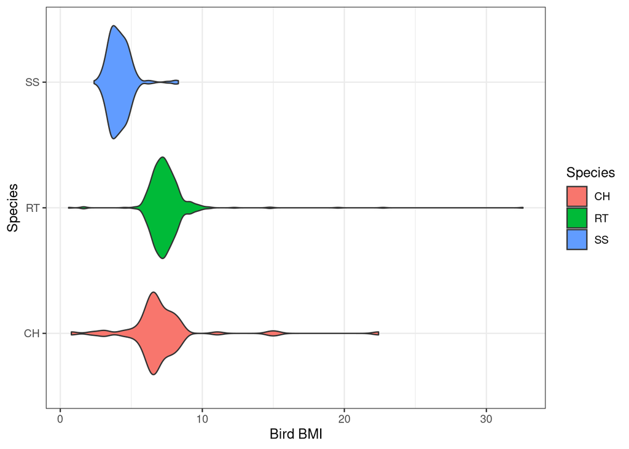

```r
filtered_hawksWithBMI <- filter(hawksWithBMI, bird_BMI < 100)
ggplot(data = filtered_hawksWithBMI, mapping = aes(x=bird_BMI, y=Species, fill=Species)) +
  geom_violin() +
  xlab("Bird BMI") +
  ylab("Species") +
  theme_bw()
```

### 2.5) Summarize and Group-by functions

```r
# Create a summary table (using summarize, groupby), broken down by Hawk species containing following quantities:
# Number of rows
# Mean average wing span in cm
# Median wing span in cm
# Trimmed mean average wing span in centimeters (trim=0.1)
# Mean average of the ratio between wing span and tail length
# Note: we need to divide values by 10 to get cm, as in mm by default
hawksFullName %>%
  group_by(Species) %>%
  summarize (
    num_rows=n(), mn_wing=mean(Wing/10, na.rm=TRUE), md_wing=median(Wing/10, na.rm=TRUE), t_mn_wing=mean(Wing/10, na.rm=TRUE, trim=0.1), tail_wing_ratio = mean(Wing/Tail, na.rm=TRUE)
  )
```

```
## # A tibble: 3 × 6
##   Species       num_rows mn_wing md_wing t_mn_wing tail_wing_ratio
##   <chr>            <int>   <dbl>   <dbl>     <dbl>           <dbl>
## 1 Cooper's            70    24.4    24        24.3            1.22
## 2 Red-tailed         577    38.3    38.4      38.5            1.73
## 3 Sharp-shinned      261    18.5    19.1      18.4            1.26
```

```r
# Then create summary table of following form:
# No. of missing values broken down by species, for specified columns
hawksFullName %>%
  select(Species, Wing, Weight, Culmen, Hallux, Tail, StandardTail, Tarsus, Crop) %>%
  group_by(Species) %>%
  summarize(across(everything(), ~sum(is.na(.x))))
```

```
## # A tibble: 3 × 9
##   Species        Wing Weight Culmen Hallux  Tail StandardTail Tarsus  Crop
##   <chr>         <int>  <int>  <int>  <int> <int>        <int>  <int> <int>
## 1 Cooper's          1      0      0      0     0           19     62    21
## 2 Red-tailed        0      5      4      3     0          250    538   254
## 3 Sharp-shinned     0      5      3      3     0           68    233    68
```

## 3) Exploratory Data Analysis

### 3.1) Combining location estimators with summarise function

```r
# Compute sample mean, sample median, and trimmed sample mean (with q = 0.1)
Hawks %>%
  summarise(
    Wing_mean=mean(Wing, na.rm=TRUE), Wing_t_mean=mean(Wing, na.rm=TRUE, trim=0.1), Wing_med=median(Wing, na.rm=TRUE), Weight_mean=mean(Weight, na.rm=TRUE), Weight_t_mean=mean(Weight, na.rm=TRUE, trim=0.1), Weight_med=median(Weight, na.rm=TRUE)
  )
```

```
##   Wing_mean Wing_t_mean Wing_med Weight_mean Weight_t_mean Weight_med
## 1  315.6375    322.2297      370    772.0802      779.3681        970
```

```r
# Combining with group_by for species break down
Hawks %>%
  group_by(Species) %>%
  summarise(
    Wing_mean=mean(Wing, na.rm=TRUE), Wing_t_mean=mean(Wing, na.rm=TRUE, trim=0.1), Wing_med=median(Wing, na.rm=TRUE), Weight_mean=mean(Weight, na.rm=TRUE), Weight_t_mean=mean(Weight, na.rm=TRUE, trim=0.1), Weight_med=median(Weight, na.rm=TRUE)
  )
```

```
## # A tibble: 3 × 7
##   Species Wing_mean Wing_t_mean Wing_med Weight_mean Weight_t_mean Weight_med
##   <fct>       <dbl>       <dbl>    <dbl>       <dbl>         <dbl>      <dbl>
## 1 CH           244.        243.      240        420.          410.       378.
## 2 RT           383.        385.      384       1094.         1089.      1070
## 3 SS           185.        184.      191        148.          140.       155
```

### 3.2) Location and dispersion estimators under linear transformations

Suppose that a variable of interest $X_i$ has values $X_1, ..., X_n$. Suppose that $X_1, ..., X_n$ has sample mean $\hat{\mu}$. Let $a, b \in \Bbb R$ be real numbers and define a new variable $\tilde{X}_i$ with values $\tilde{X}_1, ..., \tilde{X}_n$ defined by $\tilde{X}_i = a \cdot X_i + b$ for $i=1, ..., n$. Show that $\tilde{X}_1, ..., \tilde{X}_n$ has sample mean $a \cdot \hat{\mu} + b$.

$$\begin{aligned}
E(\tilde{X}) &= \frac{\sum_{i=1}^{n}{\tilde{X}_i}}{n} \\
&= \frac{\sum_{i=1}^{n}{(a \cdot X_i + b)}}{n} \\
&= \frac{a \cdot n \cdot \sum_{i=1}^{n}{X_i} + b \cdot n}{n} \\
&= \frac{n (a \cdot \hat{\mu} + b)}{n} \\
&= a \cdot \hat{\mu} + b \\
&= aE(X)+b
\end{aligned}$$

Suppose further that $X_1, ..., X_n$ has sample variance $S_X^2$. What is the sample variance of $\tilde{X}_1, ..., \tilde{X}_n$?

$$\begin{aligned}
S_\tilde{X}^2 &= \frac{\Sigma(\tilde{X}-E(\tilde{X}))^2}{n} \\
&= \frac{\Sigma(aX + b - aE(X)-b)^2}{n} \\
&= \frac{\Sigma(a(X-E(X)))^2}{n} \\
&= \frac{a^2(X-E(X))^2}{n} \\
&= a^2S_X^2
\end{aligned}$$

What is the sample standard deviation of $\tilde{X}_1, ..., \tilde{X}_n$?

$$\text{Sample Standard Deviation} = S_\tilde{X} = \sqrt{S_\tilde{X}^2} = \sqrt{a^2S_X^2} = aS_X$$

### 3.3) Robustness of location estimators

```r
# Begin by exxtracting vector of hallux lengths without means
hal <- Hawks$Hallux
hal <- hal[!is.na(hal)]

# Generate new vector (corrupted_hal) with 10 outliers, each of value 100, to investigate effect of outliers
outlier_val <- 100
num_outliers <- 10
corrupted_hal <- c(hal, rep(outlier_val, times=num_outliers))

# Compute mean of original and corrupted
mean(hal) # 26.41086
```

```
## [1] 26.41086
```

```r
mean(corrupted_hal) # 27.21776
```

```
## [1] 27.21776
```

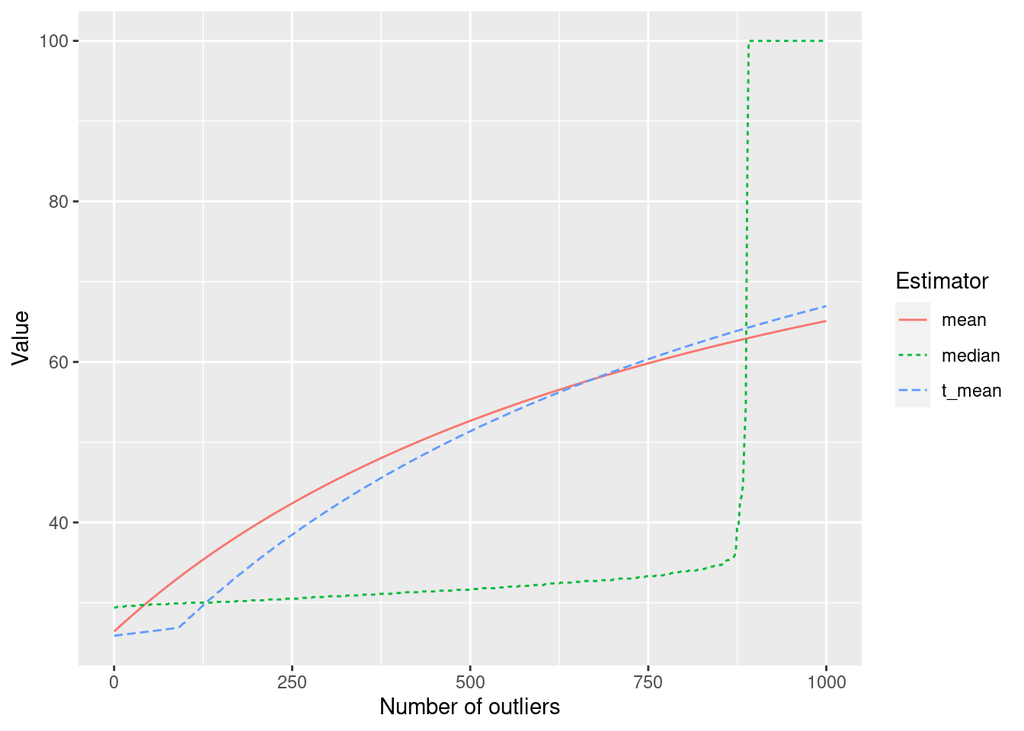

```r
# Already, corrupted mean shifted slightly higher (positive skew)

# Now investigate what happens with more outliers (increasing from 0 to 1000)
num_outliers_vect <- seq(0, 1000)
means_vect <- c()
t_means_vect <- c()
medians_vect <- c()

for (num_ouliers in num_outliers_vect) {
  corrupted_hal <- c(hal, rep(outlier_val, times=num_ouliers))
  means_vect <- c(means_vect, mean(corrupted_hal))
  t_means_vect <- c(t_means_vect, mean(corrupted_hal, trim=0.1))
  medians_vect <- c(medians_vect, median(corrupted_hal))
}

df_means_medians <- data.frame(num_outliers=num_outliers_vect, mean=means_vect, t_mean=t_means_vect, median=medians_vect)

df_means_medians %>%
  pivot_longer(!num_outliers, names_to = "Estimator", values_to = "Value") %>%
  ggplot( aes(x=num_outliers, color=Estimator, linetype=Estimator, y=Value)) +
  geom_line() + xlab("Number of outliers")
```

### 3.4) Box plots and outliers

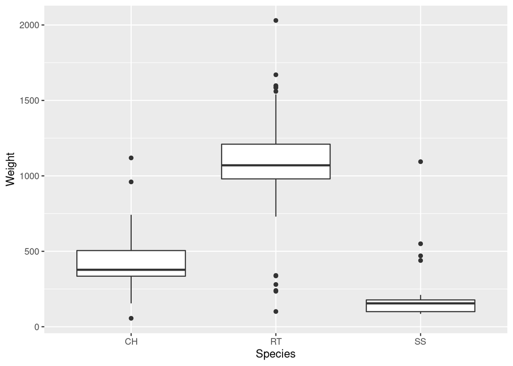

```r
ggplot(data = Hawks, mapping = aes(x=Species, y=Weight)) +
  geom_boxplot()
```

```r
num_outliers <- function(X) {
  # This function takes in a sample, X, and outputs the number of outliers

  # Calculate the upper and lower quartile, and IQR
  q75 <- quantile(X, 0.75, na.rm=TRUE)
  q25 <- quantile(X, 0.25, na.rm=TRUE)
  IQ_Range <- q75 - q25

  # Find upper and lower bounds for X
  X_upper <- q75 + 1.5 * IQ_Range
  X_lower <- q25 - 1.5 * IQ_Range

  # Find all outliers
  outliers <- X[(X > X_upper) | (X < X_lower)]

  # Find number of outliers by counting non-na items
  num_of_outliers <- sum(!is.na(outliers))
  return(num_of_outliers)
}

# Find number of outliers for one-off example
# num_outliers(filter(Hawks, Species=="SS")$Weight)

# Find summary of outliers for weight
Hawks %>%
  group_by(Species) %>%
  summarise(
    num_outliers_weight = num_outliers(Weight)
  )
```

```
## # A tibble: 3 × 2
##   Species num_outliers_weight
##   <fct>                 <int>
## 1 CH                        3
## 2 RT                       13
## 3 SS                        4
```

### 3.5) Covariance and correlation under linear transformations

Suppose that we have a pair of variables: $X_i$ with values $X_1, ..., X_n$ and $Y_i$ with values $Y_1, ..., Y_n$. Suppose that $X_1, ..., X_n$ and $Y_1, ..., Y_n$ have sample covariance $\Sigma_{X,Y}$. Let $a, b \in \Bbb R$ be real numbers and define a new variable $\tilde{X}_i$ with values $\tilde{X}_1, ..., \tilde{X}_n$ defined by $\tilde{X}_i = a \cdot X_i + b$ for $i = 1, ..., n$. In addition, let $c, d \in \Bbb R$ be real numbers and define a new variable $\tilde{Y}_i$ with values $\tilde{Y}_1, ..., \tilde{Y}_n$ defined by $\tilde{Y}_i = c \cdot Y_i + d$ for $i = 1, .., n$. What is the covariance between the pair of variables $\tilde{X}_1, ..., \tilde{X}_n$ and $\tilde{Y}_1, ..., \tilde{Y}_n$?

$$\begin{aligned}
cov_{\tilde{X},\tilde{Y}} &= \frac{\Sigma(\tilde{X}-E(\tilde{X}))(\tilde{Y}-E(\tilde{Y}))}{N-1} \\
&= \frac{\Sigma(aX+b-aE(X)-b)(cY+d-cE(Y)-d)}{N-1} \\
&= \frac{a \cdot c \cdot \Sigma(X-E(X))(Y-E(Y))}{N-1} \\
&= a \cdot c \cdot cov_{X,Y}
\end{aligned}$$

Suppose that $X_1, ..., X_n$ and $Y_1, ..., Y_n$ have correlation $\rho_{X, Y}$. What is the correlation of variables $\tilde{X}_1, ..., \tilde{X}_n$ and $\tilde{Y}_1, ..., \tilde{Y}_n$?

$$\begin{aligned}
\rho_{\tilde{X}, \tilde{Y}} &= \frac{\Sigma(\tilde{X}-E(\tilde{X}))(\tilde{Y}-E(\tilde{Y}))}{\sqrt{\Sigma(\tilde{X}-E(\tilde{X}))^2\Sigma(\tilde{Y}-E(\tilde{Y}))^2}} \\
&= \frac{cov_{\tilde{X},\tilde{Y}}}{S_\tilde{X}S_\tilde{Y}} \\
&= \frac{a \cdot c \cdot cov_{X,Y}}{a \cdot S_X \cdot c \cdot S_Y} \\
&= \frac{cov_{X,Y}}{S_X S_Y} \\
&= \rho_{X,Y}
\end{aligned}$$